# OpenIntro Statistics: Chapter 2

# Transforming Data

## Extremely skewed data

When data are extremely skewed, transforming them might make modeling easier. A common transformation is the **log transformation**.

. . .

The histograms on the left show the distribution of number of basketball games attended by students. The histogram on the right shows the distribution of log of number of games attended.

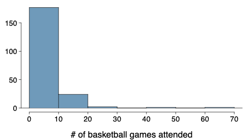

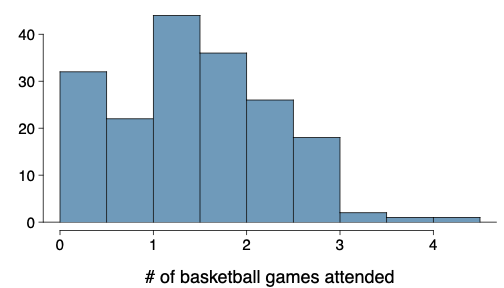

## Pros and cons of transformations

- Skewed data are easier to model with when they are transformed because outliers tend to become far less prominent after an appropriate transformation.

  | # of games | 70 | 50 | 25 | ⋯ |
  | --- | --- | --- | --- | --- |
  | log(# of games) | 4.25 | 3.91 | 3.22 | ⋯ |

- However, results of an analysis in log units of the measured variable might be difficult to interpret.

. . .

> **Q:** What other variables would you expect to be extremely skewed?

. . .

> **A:** Salary, housing prices, etc.

# Mapping Data

## Intensity maps

> **Q:** What patterns are apparent in the change in population between 2000 and 2010?

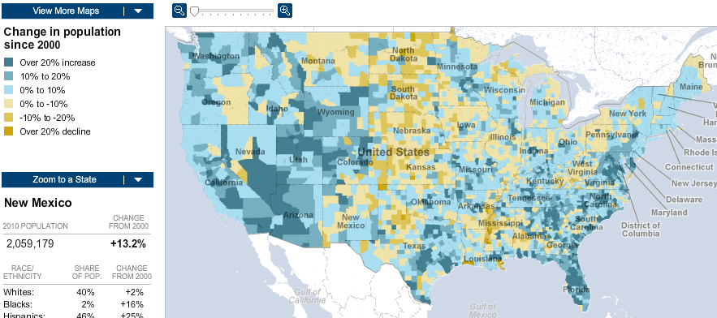

> [Source](http://projects.nytimes.com/census/2010/map)

# Considering categorical data

# Contingency tables and bar plots

## Contingency tables

A table that summarizes data for two categorical variables is called a **contingency table**.

. . .

The contingency table below shows the distribution of survival and ages of passengers on the Titanic.

| Age | Died | Survived | Total |
| --- | --- | --- | --- |
| Adult | 1438 | 654 | 2092 |
| Child | 52 | 57 | 109 |
| Total | 1490 | 711 | 2201 |

## Bar plots

A **bar plot** is a common way to display a single categorical variable.  
A bar plot where proportions instead of frequencies are shown is called a **relative frequency bar plot**.

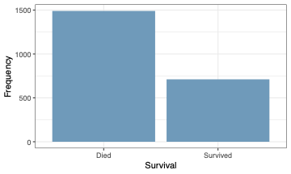

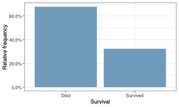

## Bar plots (continued)

**Discussion Question:**  
*How are bar plots different than histograms?*

. . .

-Bar plots are used for displaying distributions of categorical variables,  
histograms are used for numerical variables.

. . .

-The x-axis in a histogram is a number line, hence the order of the bars cannot be changed.

. . .

-In a bar plot, the categories can be listed in any order (though some orderings make more sense than others, especially for ordinal variables).

# Row and column proportions

## Choosing the appropriate proportion

**Discussion Question:**  
Does there appear to be a relationship between age and survival for passengers on the Titanic?

| Age | Died | Survived | Total |
| --- | --- | --- | --- |
| Adult | 1438 | 654 | 2092 |
| Child | 52 | 57 | 109 |
| Total | 1490 | 711 | 2201 |

. . .

To answer this question we examine the row proportions:

. . .

- % Adults who survived: 654 / 2092 ≈ 0.31

. . .

- % Children who survived: 57 / 109 ≈ 0.52

# Using a bar plot with two variables

## Bar plots with two variables

- **Stacked bar plot:** Graphical display of contingency table information, for counts.
- **Side-by-side bar plot:** Displays the same information by placing bars next to, instead of on top of, each other.
- **Standardized stacked bar plot:** Graphical display of contingency table information, for proportions.

## Bar plots with two variables (continued)

**Discussion Question:**  
What are the differences between the three visualizations shown below?

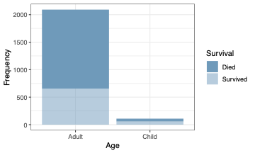

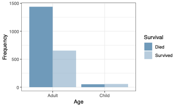

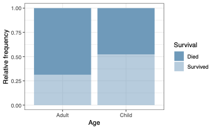

# Mosaic plots

## Mosaic plots

**Discussion Question:**  
What is the difference between the two visualizations shown below?

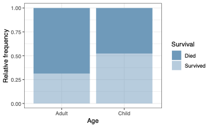

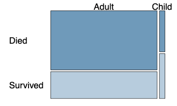

# Pie charts

## Pie charts

**Discussion Question:**  
Can you tell which order encompasses the lowest percentage of mammal species?

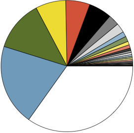

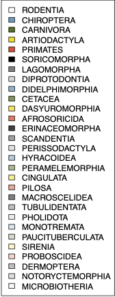

Data from http://www.bucknell.edu/msw3.

# Comparing numerical data across groups

## Side-by-side box plots

**Discussion Question:**  
Does there appear to be a relationship between class year and number of clubs students are in?

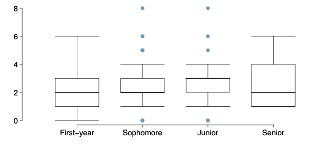

# Case study: Gender discrimination

# Study description and data

## Gender discrimination

- In 1972, as a part of a study on gender discrimination, 48 male bank supervisors were each given the same personnel file and asked to judge whether the person should be promoted to a branch manager job that was described as “routine”.
- The files were identical except that half of the supervisors had files showing the person was male while the other half had files showing the person was female.
- It was randomly determined which supervisors got “male” applications and which got “female” applications.
- Of the 48 files reviewed, 35 were promoted.
- The study is testing whether females are unfairly discriminated against.

. . .

**Discussion Question:**  
Is this an observational study or an experiment?

. . .

**Answer:** Experiment

B. Rosen and T. Jerdee (1974), “Influence of sex role stereotypes on personnel decisions”, *J. Applied Psychology*, 59:9–14.

## Data

**Discussion Question:**  
At a first glance, does there appear to be a relationship between promotion and gender?

| Gender | Promoted | Not Promoted | Total |
| --- | --- | --- | --- |
| Male | 21 | 3 | 24 |
| Female | 14 | 10 | 24 |
| Total | 35 | 13 | 48 |

. . .

**% of males promoted:** 21 / 24 = 0.875  
**% of females promoted:** 14 / 24 = 0.583

## Practice

**Practice Question:**  
We saw a difference of almost 30% (29.2% to be exact) between the proportion of male and female files that are promoted. Based on this information, which of the below is true?

1. If we were to repeat the experiment we will definitely see that more female files get promoted. This was a fluke.
2. Promotion is dependent on gender, males are more likely to be promoted, and hence there is gender discrimination against women in promotion decisions.

. . .

3. The difference in the proportions of promoted male and female files is due to chance; this is not evidence of gender discrimination against women in promotion decisions.

. . .

4. Women are less qualified than men, and this is why fewer females get promoted.

# Competing claims

## Two competing claims

1. “There is nothing going on.”  
   Promotion and gender are **independent**, no gender discrimination, observed difference in proportions is simply due to chance. → **Null hypothesis**

. . .

2. “There is something going on.”  
   Promotion and gender are **dependent**, there is gender discrimination, observed difference in proportions is not due to chance. → **Alternative hypothesis**

## A trial as a hypothesis test

- Hypothesis testing is very much like a court trial.
- **H₀**: Defendant is innocent  
  **Hₐ**: Defendant is guilty
- We then present the evidence — collect data.
- Then we judge the evidence — “Could these data plausibly have happened by chance if the null hypothesis were true?”

[figure not shown]

- If they were very unlikely to have occurred, then the evidence raises more than a reasonable doubt in our minds about the null hypothesis.
- Ultimately we must make a decision. How unlikely is unlikely?

## A trial as a hypothesis test (continued)

- If the evidence is not strong enough to reject the assumption of innocence, the jury returns with a verdict of “not guilty.”
- The jury does not say that the defendant is innocent, just that there is not enough evidence to convict.
- The defendant may, in fact, be innocent, but the jury has no way of being sure.
- Said statistically, we fail to reject the null hypothesis.
  - We never declare the null hypothesis to be true, because we simply do not know whether it’s true or not.
  - Therefore we never “accept the null hypothesis.”

## A trial as a hypothesis test (continued)

- In a trial, the burden of proof is on the prosecution.
- In a hypothesis test, the burden of proof is on the unusual claim.
- The null hypothesis is the ordinary state of affairs (the status quo), so it’s the alternative hypothesis that we consider unusual and for which we must gather evidence.

## Recap: hypothesis testing framework

- We start with a **null hypothesis (H₀)** that represents the status quo.
- We also have an **alternative hypothesis (Hₐ)** that represents our research question, i.e., what we’re testing for.
- We conduct a hypothesis test under the assumption that the null hypothesis is true, either via simulation (today) or theoretical methods (later in the course).
- If the test results suggest that the data do not provide convincing evidence for the alternative hypothesis, we stick with the null hypothesis. If they do, then we reject the null hypothesis in favor of the alternative.

# Testing via simulation

## Simulating the experiment…

… under the assumption of independence, i.e., leave things up to chance.

. . .

If results from the simulations based on the **chance model** look like the data, then we can determine that the difference between the proportions of promoted files between males and females was simply **due to chance** (promotion and gender are independent).

. . .

If the results from the simulations based on the chance model do not look like the data, then we can determine that the difference between the proportions of promoted files between males and females was not due to chance, but **due to an actual effect of gender** (promotion and gender are dependent).

## Application activity: simulating the experiment

**Activity:**  
Use a deck of playing cards to simulate this experiment.

1. Let a face card represent *not promoted* and a non-face card represent *promoted*. Consider aces as face cards.
   - Set aside the jokers.
   - Take out 3 aces → there are exactly 13 face cards left in the deck (face cards: A, K, Q, J).
   - Take out a number card → there are exactly 35 number (non-face) cards left in the deck (number cards: 2–10).
2. Shuffle the cards and deal them into two groups of size 24, representing males and females.
3. Count and record how many files in each group are promoted (number cards).
4. Calculate the proportion of promoted files in each group and take the difference (male − female), and record this value.
5. Repeat steps 2–4 many times.

## Step 1

[figure not shown]

## Step 2 - 4

[figure not shown]

#Checking for independence

## Practice

**Practice Question:**  
Do the results of the simulation you just ran provide convincing evidence of gender discrimination against women, i.e., dependence between gender and promotion decisions?

1. No, the data do not provide convincing evidence for the alternative hypothesis, therefore we can’t reject the null hypothesis of independence between gender and promotion decisions. The observed difference between the two proportions was due to chance.

. . .

**Answer:** Yes, the data provide convincing evidence for the alternative hypothesis of gender discrimination against women in promotion decisions. The observed difference between the two proportions was due to a real effect of gender.

## Simulations using software

These simulations are tedious and slow to run using the method described earlier. In reality, we use software to generate the simulations. The dot plot below shows the distribution of simulated differences in promotion rates based on 100 simulations.

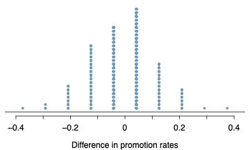